# Homework6_115

## Due Friday 11/08 at 10pm.

This assignment has 25 points possible. Your score will be calculated out of 22 points and scaled to be out of 5 points.

# Question 1 – Sex Equality (4 pts)

The General Social Survey asked a random sample of 1,390 Americans the following question: “On the whole, do you think it should or should not be the government’s responsibility to promote equality between men and women?” 82% of the respondents said it “should be”. At a 95% confidence level, this sample has 2% margin of error. Based on this information, determine if the following statements are true or false, and explain your reasoning. (NORC 2016)

**Part A**: We are 95% confident that 80% to 84% of Americans in this sample think it’s the government’s responsibility to promote equality between men and women.

**Part B**: We are 95% confident that 80% to 84% of all Americans think it’s the government’s responsibility to promote equality between men and women.

**Part C**: If we considered many random samples of 1,390 Americans, and we calculated 95% confidence intervals for each, 95% of these intervals would include the true population proportion of Americans who think it’s the government’s responsibility to promote equality between men and women.

**Part D**: In order to decrease the margin of error to 1%, we would need to quadruple (multiply by 4) the sample size.

# Question 2 – Proof of COVID-19 vaccination (6 pts)

In the US, businesses and schools shut down due to the COVID-19 pandemic in March 2020, and a vaccine became publicly available for the first time in April 2021. That month, a Gallup poll surveyed a random sample of 3,731 US adults, asking how they felt about the COVID-19 vaccine requirement for air travel. The poll found that 57% said they would favor it. (Gallup 2021b)

**Part A**: Describe the population parameter of interest.

**Part C**: Construct a 95% confidence interval for the proportion of US adults who favored requiring proof of COVID-19 vaccination for travel by airplane. (Show work and final value)

**Part D**: Interpret the confidence interval.

**Part E**: Without doing any calculations, describe what would happen to the confidence interval if we decided to use a higher confidence level.

**Part F**: Without doing any calculations, describe what would happen to the confidence interval if we used a larger sample.

# Question 3 – Is Yawning Contagious? (3 pts)

Is yawning contagious? An experiment conducted by the MythBusters, a science entertainment TV program on the Discovery Channel, tested if a person can be subconsciously influenced into yawning if another person near them yawns. 50 people were randomly assigned to two groups: 34 to a group where a person near them yawned (treatment) and 16 to a group where there wasn’t a person yawning near them (control). The visualization below displays how many participants yawned in each group.

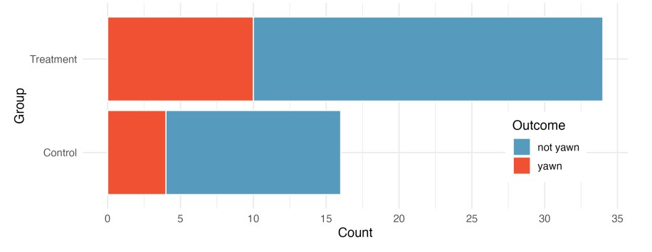

```r
knitr::include_graphics("https://nfriedrichsen.github.io/homework/mythbusters-chart.jpg")
```

Suppose we are interested in estimating the difference in yawning rates between the control and treatment groups using a confidence interval. Explain why we cannot construct such an interval using the normal approximation. What might go wrong if we constructed the confidence interval despite this problem?

# Question 4 – Sleep deprivation (5 pts)

A CDC report on sleep deprivation rates shows that the proportion of California residents who reported insufficient rest or sleep during each of the preceding 30 days is 8.0%, while this proportion is 8.8% for Oregon residents. These data are based on simple random samples of 11,545 California and 4,691 Oregon residents.

Construct a 90% confidence interval for the difference in proportions (Oregon - California) and interpret the interval in context.

# Question 5 – Rainbow Trout (7 pts)

Rainbow trout were captured using 2 different types of nets; Sinking Net and Floating Net. It is hypothesized that the Sinking Net will be more effective in catching smaller fish. Out of all of the rainbow trout caught, a random sample of 71 fish caught using the sinking net was examined and a random sample of 52 fish caught using the floating net was examined.

**Research Question:** Estimate the difference in pop. mean length (mm) for fish caught with the floating net vs. the sinking net

#### Sinking Net Fish

The average length (mm) for the fish caught in the Sinking Net was 254.972 with a standard deviation of 73.619.

#### Floating Net Fish

The average length (mm) for the fish caught in the Floating Net was 278.846 with a standard deviation of 70.653.

**Part A**: Are the conditions met to make a 90% CI for difference in means for these samples? Explain.

**Part B**: Regardless of your answer to Part A, create a 90% CI for the difference in pop. means. (show work for credit). The $t^*$ value needed is

```r
qt(.95, df=51)
```

```
## [1] 1.675285
```

**Part C**: Interpret the confidence interval in context.

**Part D**: Is it plausible there is no difference in the pop. means according to the CI?